# WHAT IS NHANES?

The NHANES survey is conducted by the US CDC. [More about NHANES](https://www.cdc.gov/nchs/nhanes/about/index.html). These surveys have been conducted since the 1960’s.

Starting in 1999, about 5,000 individuals of all ages have been interviewed every year and then they complete the health examination component of the survey. Part of this dataset is made available via the NHANES package which can be loaded this way:

```r
data(NHANES)
dim(NHANES)
```

```
[1] 10000    76
```

Before we start, it is necessary run the packages that we are going to use, in this case would be:

```r
library(tidyverse)
library(gtsummary)
library(NHANES)
library(ggplot2)
library(scales)
```

## **Is sleep trouble associated with Type II diabetes, after adjusting other factors?**

It has been shown that there is a relationship between type II diabetes and sleep problems, several studies suggest that sleep problems are associated with an increased risk of developing type II diabetes. Sleep trouble may alter metabolic, endocrine, and inflammatory pathways, thereby increasing diabetes risk (Cappuccio et al., 2010; Darraj, 2023).

Furthermore, factors such as depression, higher body mass index (BMI), older age, lower socioeconomic status, education, and some racial and ethnic background have all been linked to higher rates of diabetes (Knol et al., 2006; Hill-Briggs et al., 2021; Spanakis & Golden, 2013).

### Hypothesis

People with sleep trouble are more likely to have diabetes type II, even after adjusting for other risk factors

### Preparing the data

Select only the data that we will use.

```r
NHANES %>% select(Diabetes, SleepTrouble, Age, BMI, PhysActive, Education, Race1, Depressed, Poverty, Gender)
```

| Diabetes | SleepTrouble | Age | BMI | PhysActive | Education | Race1 | Depressed | Poverty | Gender |
| --- | --- | --- | --- | --- | --- | --- | --- | --- | --- |
| No | Yes | 34 | 32.22 | No | High School | White | Several | 1.36 | male |
| No | Yes | 34 | 32.22 | No | High School | White | Several | 1.36 | male |
| No | Yes | 34 | 32.22 | No | High School | White | Several | 1.36 | male |
| No | NA | 4 | 15.30 | NA | NA | Other | NA | 1.07 | male |
| No | Yes | 49 | 30.57 | No | Some College | White | Several | 1.91 | female |
| No | NA | 9 | 16.82 | NA | NA | White | NA | 1.84 | male |
| No | NA | 8 | 20.64 | NA | NA | White | NA | 2.33 | male |
| No | No | 45 | 27.24 | Yes | College Grad | White | None | 5.00 | female |
| No | No | 45 | 27.24 | Yes | College Grad | White | None | 5.00 | female |
| No | No | 45 | 27.24 | Yes | College Grad | White | None | 5.00 | female |

[output cut: 990 more lines]

```r
Sleep_data <-NHANES %>% select(Diabetes, SleepTrouble, Age, BMI, PhysActive, Education, Race1, Depressed, Poverty, Gender) %>% filter(!is.na(Diabetes),!is.na(SleepTrouble), !is.na(Age), !is.na(BMI), !is.na(Education), !is.na(Race1),  !is.na(Depressed), !is.na(Poverty),!is.na(Gender))
summary(Sleep_data)
```

```
 Diabetes   SleepTrouble      Age             BMI        PhysActive          Education
 No :5350   No :4369     Min.   :20.00   Min.   :15.02   No :2747   8th Grade     : 296
 Yes: 626   Yes:1607     1st Qu.:33.00   1st Qu.:24.24   Yes:3229   9 - 11th Grade: 694
                         Median :47.00   Median :27.90              High School   :1263
                         Mean   :47.37   Mean   :28.92              Some College  :1910
                         3rd Qu.:60.00   3rd Qu.:32.36              College Grad  :1813
                         Max.   :80.00   Max.   :81.25
      Race1        Depressed       Poverty         Gender
 Black   : 617   None   :4717   Min.   :0.000   female:2966
 Hispanic: 320   Several: 901   1st Qu.:1.390   male  :3010
 Mexican : 451   Most   : 358   Median :3.030
 White   :4175                  Mean   :2.992
 Other   : 413                  3rd Qu.:5.000
                                Max.   :5.000
```

### Exploratory graphs by variable

To have an overview of the relationship between diabetes and other factors, a graphic model of each of them was created.

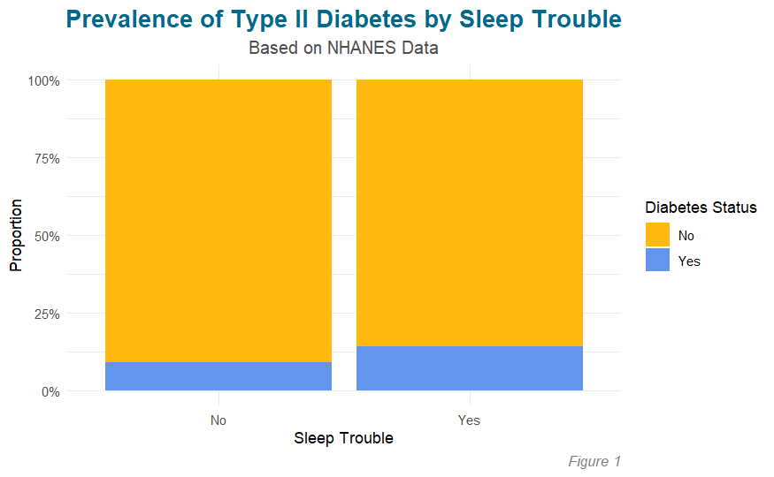

```r
Sleep_data %>%
  ggplot(aes(x=SleepTrouble, fill= Diabetes )) +
  geom_bar(position="fill") +
  scale_y_continuous(labels = scales::percent) +
  labs(
  y = "Proportion",
  title = "Prevalence of Type II Diabetes by Sleep Trouble",
    subtitle = "Based on NHANES Data",
    x = "Sleep Trouble",
    y = "Proportion",
    fill = "Diabetes Status",
    caption = "Figure 1") +
  theme_minimal() +
  scale_fill_manual(values = c("No" = "darkgoldenrod1",
                               "Yes" = "cornflowerblue")) +
  theme(
    plot.title = element_text(hjust = 0.5,  color = "deepskyblue4", size = 16, face = "bold"),
    plot.subtitle = element_text(hjust = 0.5, color = "gray30", size = 12),
    plot.caption = element_text(hjust = 1,  color = "gray50", size = 10, face = "italic")
  )
```

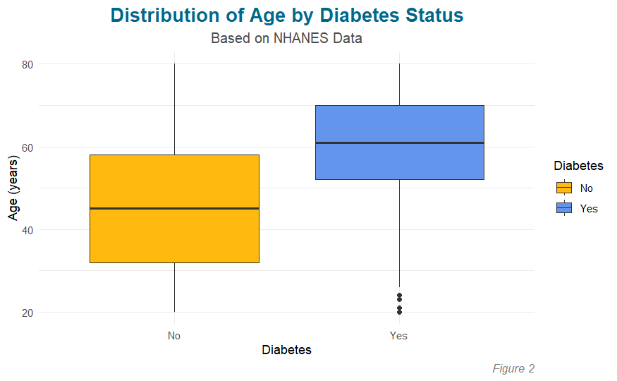

```r
Sleep_data %>%
  ggplot(aes(x = Diabetes, y = Age, fill = Diabetes)) +
  geom_boxplot() +
  labs(
    title = "Distribution of Age by Diabetes Status",
    subtitle = "Based on NHANES Data",
    x = "Diabetes",
    y = "Age (years)",
    fill = "Diabetes",
    caption = "Figure 2") +
  theme_minimal() +
  scale_fill_manual(values = c("No" = "darkgoldenrod1", "Yes" = "cornflowerblue")) +
  theme(
    plot.title = element_text(hjust = 0.5, color = "deepskyblue4", size = 16, face = "bold"),
    plot.subtitle = element_text(hjust = 0.5, color = "gray30", size = 12),
    plot.caption = element_text(hjust = 1, color = "gray50", size = 10, face = "italic")
  )
```

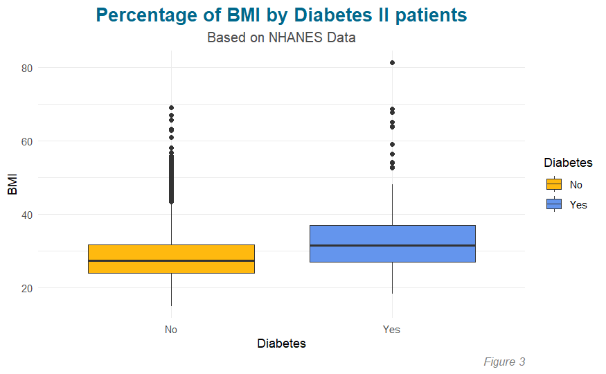

```r
Sleep_data %>%
  ggplot(aes(x=Diabetes, y=BMI, fill= Diabetes )) +
  geom_boxplot()+
  labs(
    title = "Percentage of BMI by Diabetes II patients",
    subtitle = "Based on NHANES Data",
    x = "Diabetes",
    y = "BMI",
    fill = "Diabetes",
    caption = "Figure 3") +
  theme_minimal() +
    scale_fill_manual(values = c("No" = "darkgoldenrod1",
                               "Yes" = "cornflowerblue")) +
  theme(
    plot.title = element_text(hjust = 0.5,  color = "deepskyblue4", size = 16, face = "bold"),
    plot.subtitle = element_text(hjust = 0.5, color = "gray30", size = 12),
    plot.caption = element_text(hjust = 1,  color = "gray50", size = 10, face = "italic")
  )
```

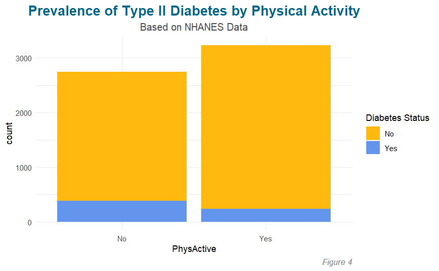

```r
Sleep_data %>%
  ggplot(aes(x=PhysActive, fill= Diabetes)) +
  geom_bar() +
  labs(
    y = "count",
    title = "Prevalence of Type II Diabetes by Physical Activity",
    subtitle = "Based on NHANES Data",
    x = "PhysActive",
    y = "count",
    fill = "Diabetes Status",
    caption = "Figure 4") +
  theme_minimal()  +
  scale_fill_manual(values = c("No" = "darkgoldenrod1",
                               "Yes" = "cornflowerblue")) +
  theme(
    plot.title = element_text(hjust = 0.5,  color = "deepskyblue4", size = 16, face = "bold"),
    plot.subtitle = element_text(hjust = 0.5, color = "gray30", size = 12),
    plot.caption = element_text(hjust = 1,  color = "gray50", size = 10, face = "italic")
  )
```

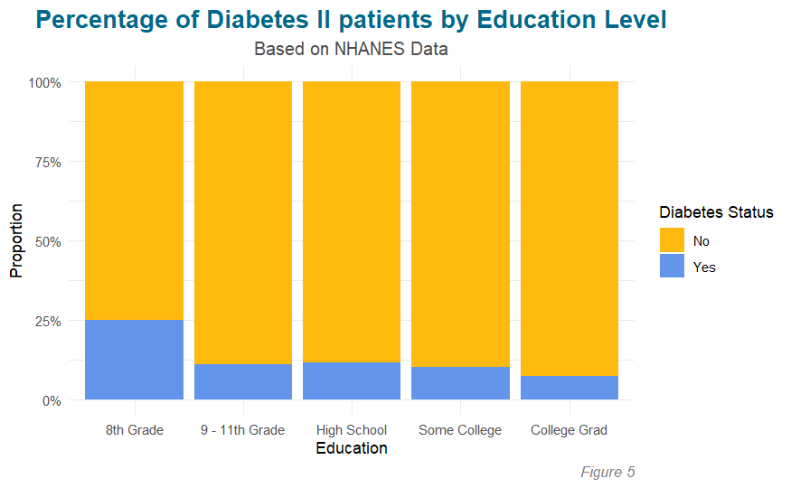

```r
Sleep_data %>%
  ggplot(aes(x = Education, fill = Diabetes)) +
  geom_bar(position = "fill") +
  scale_y_continuous(labels = scales::percent) +
  labs(
    y = "Proportion",
    title = "Percentage of Diabetes II patients by Education Level",
    subtitle = "Based on NHANES Data",
    x = "Education",
    y = "Proportion",
    fill = "Diabetes Status",
    caption = "Figure 5")+
  theme_minimal()  +
  scale_fill_manual(values = c("No" = "darkgoldenrod1",
                               "Yes" = "cornflowerblue")) +
  theme(
    plot.title = element_text(hjust = 0.5,  color = "deepskyblue4", size = 16, face = "bold"),
    plot.subtitle = element_text(hjust = 0.5, color = "gray30", size = 12),
    plot.caption = element_text(hjust = 1,  color = "gray50", size = 10, face = "italic")
  )
```

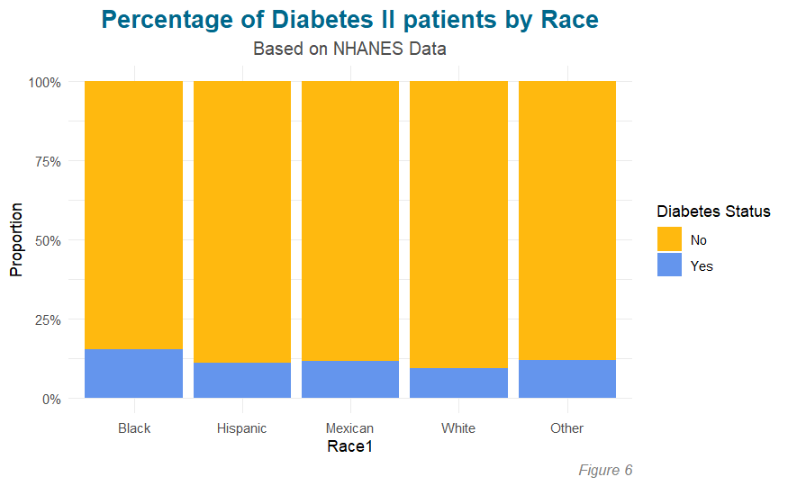

```r
Sleep_data %>%
  ggplot(aes(x = Race1, fill = Diabetes)) +
  geom_bar(position = "fill") +
  scale_y_continuous(labels = scales::percent) +
  labs(
    y = "Proportion",
    title = "Percentage of Diabetes II patients by Race",
    subtitle = "Based on NHANES Data",
    x = "Race1",
    y = "Proportion",
    fill = "Diabetes Status",
    caption = "Figure 6") +
  theme_minimal()  +
  scale_fill_manual(values = c("No" = "darkgoldenrod1",
                               "Yes" = "cornflowerblue")) +
  theme(
    plot.title = element_text(hjust = 0.5,  color = "deepskyblue4", size = 16, face = "bold"),
    plot.subtitle = element_text(hjust = 0.5, color = "gray30", size = 12),
    plot.caption = element_text(hjust = 1,  color = "gray50", size = 10, face = "italic")
  )
```

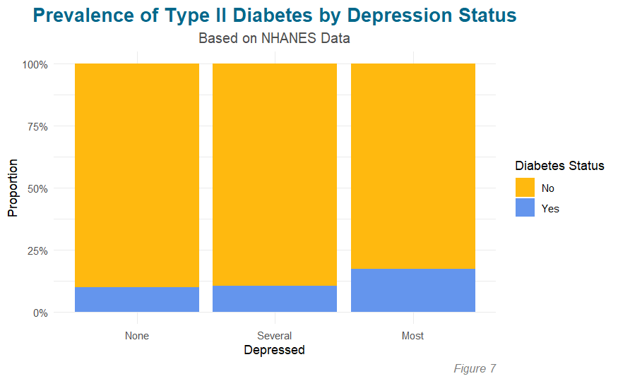

```r
Sleep_data %>%  ggplot(aes(x=Depressed, fill= Diabetes)) +
  geom_bar(position="fill") +
  scale_y_continuous(labels = scales::percent) +
  labs(y = "Proportion",
       title = "Prevalence of Type II Diabetes by Depression Status",
       subtitle = "Based on NHANES Data",
    x = "Depressed",
    y = "Proportion",
    fill = "Diabetes Status",
    caption = "Figure 7")+
  theme_minimal()  +
  scale_fill_manual(values = c("No" = "darkgoldenrod1",
                               "Yes" = "cornflowerblue")) +
  theme(
    plot.title = element_text(hjust = 0.5,  color = "deepskyblue4", size = 16, face = "bold"),
    plot.subtitle = element_text(hjust = 0.5, color = "gray30", size = 12),
    plot.caption = element_text(hjust = 1,  color = "gray50", size = 10, face = "italic")
  )
```

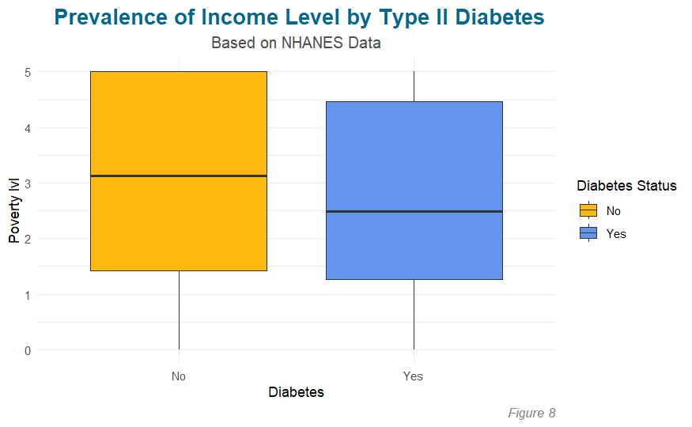

```r
Sleep_data %>%  ggplot(aes(x= Diabetes, y=Poverty, fill= Diabetes)) +
  geom_boxplot()  +
  labs(
    x= "Diabetes",
    y = "Poverty lvl",
    title = " Prevalence of Income Level by Type II Diabetes",
    subtitle = "Based on NHANES Data",
    x = "Diabetes",
    y="Poverty",
    fill = "Diabetes Status",
    caption = "Figure 8") +
  theme_minimal() +
    scale_fill_manual(values = c("No" = "darkgoldenrod1",
                               "Yes" = "cornflowerblue")) +
  theme(
    plot.title = element_text(hjust = 0.5,  color = "deepskyblue4", size = 16, face = "bold"),
    plot.subtitle = element_text(hjust = 0.5, color = "gray30", size = 12),
    plot.caption = element_text(hjust = 1,  color = "gray50", size = 10, face = "italic")
  )
```

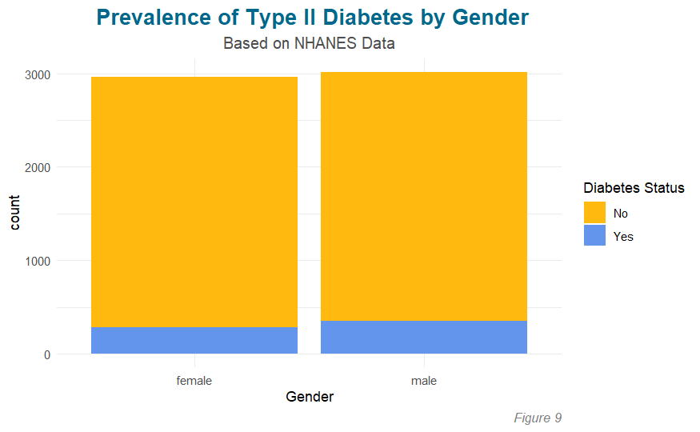

```r
Sleep_data %>%  ggplot(aes(x=Gender, fill= Diabetes)) +
  geom_bar()  +
  labs(
    y = "count",
    title = " Prevalence of Type II Diabetes by Gender",
    subtitle = "Based on NHANES Data",
    x = "Gender",
    y = "count",
    fill = "Diabetes Status",
    caption = "Figure 9") +
  theme_minimal() +
    scale_fill_manual(values = c("No" = "darkgoldenrod1",
                               "Yes" = "cornflowerblue")) +
  theme(
    plot.title = element_text(hjust = 0.5,  color = "deepskyblue4", size = 16, face = "bold"),
    plot.subtitle = element_text(hjust = 0.5, color = "gray30", size = 12),
    plot.caption = element_text(hjust = 1,  color = "gray50", size = 10, face = "italic")
  )
```

## Run logistic regression model

```r
Sleep_data_glm<-glm(Diabetes ~ SleepTrouble + Age + BMI+ PhysActive + Education + Race1 + Depressed + Poverty + Gender, data= Sleep_data, family = binomial(link = "logit"))
summary(Sleep_data_glm)
```

```
Call:
glm(formula = Diabetes ~ SleepTrouble + Age + BMI + PhysActive +
    Education + Race1 + Depressed + Poverty + Gender, family = binomial(link = "logit"),
    data = Sleep_data)

Coefficients:
                         Estimate Std. Error z value Pr(>|z|)
(Intercept)             -7.679514   0.408164 -18.815  < 2e-16 ***
SleepTroubleYes          0.366037   0.101181   3.618 0.000297 ***
Age                      0.063506   0.003343  18.999  < 2e-16 ***
BMI                      0.089367   0.006641  13.457  < 2e-16 ***
PhysActiveYes           -0.132416   0.100340  -1.320 0.186945
Education9 - 11th Grade -0.534480   0.205518  -2.601 0.009305 **
EducationHigh School    -0.310153   0.189100  -1.640 0.100974
EducationSome College   -0.279198   0.188876  -1.478 0.139353
EducationCollege Grad   -0.375137   0.205126  -1.829 0.067428 .
Race1Hispanic           -0.189107   0.236989  -0.798 0.424897
Race1Mexican             0.019979   0.215656   0.093 0.926186
Race1White              -0.652102   0.141439  -4.610 4.02e-06 ***
Race1Other               0.211098   0.214651   0.983 0.325388
DepressedSeveral         0.018067   0.133234   0.136 0.892132
DepressedMost            0.506002   0.174289   2.903 0.003693 **
Poverty                 -0.071601   0.033477  -2.139 0.032450 *
Gendermale               0.522968   0.095328   5.486 4.11e-08 ***
---
Signif. codes:  0 ‘***’ 0.001 ‘**’ 0.01 ‘*’ 0.05 ‘.’ 0.1 ‘ ’ 1

(Dispersion parameter for binomial family taken to be 1)

    Null deviance: 4008.7  on 5975  degrees of freedom
Residual deviance: 3245.2  on 5959  degrees of freedom
AIC: 3279.2

Number of Fisher Scoring iterations: 6
```

```r
odds_ratios <- exp(coef(Sleep_data_glm))
print(odds_ratios)
```

```
            (Intercept)         SleepTroubleYes                     Age
           0.0004621993            1.4420085995            1.0655655175
                    BMI           PhysActiveYes Education9 - 11th Grade
           1.0934820105            0.8759763825            0.5859740543
   EducationHigh School   EducationSome College   EducationCollege Grad
           0.7333348211            0.7563898725            0.6871953358
          Race1Hispanic            Race1Mexican              Race1White
           0.8276981502            1.0201803073            0.5209495489
             Race1Other        DepressedSeveral           DepressedMost
           1.2350328889            1.0182315769            1.6586463469
                Poverty              Gendermale
           0.9309024811            1.6870265999
```

```r
percent_change <- (odds_ratios-1)*100
print(round(percent_change, 2))
```

```
            (Intercept)         SleepTroubleYes                     Age
                 -99.95                   44.20                    6.56
                    BMI           PhysActiveYes Education9 - 11th Grade
                   9.35                  -12.40                  -41.40
   EducationHigh School   EducationSome College   EducationCollege Grad
                 -26.67                  -24.36                  -31.28
          Race1Hispanic            Race1Mexican              Race1White
                 -17.23                    2.02                  -47.91
             Race1Other        DepressedSeveral           DepressedMost
                  23.50                    1.82                   65.86
                Poverty              Gendermale
                  -6.91                   68.70
```

```r
percent_change <- odds_ratios/(1 + odds_ratios)
print(round(percent_change, 2))
```

```
            (Intercept)         SleepTroubleYes                     Age
                   0.00                    0.59                    0.52
                    BMI           PhysActiveYes Education9 - 11th Grade
                   0.52                    0.47                    0.37
   EducationHigh School   EducationSome College   EducationCollege Grad
                   0.42                    0.43                    0.41
          Race1Hispanic            Race1Mexican              Race1White
                   0.45                    0.50                    0.34
             Race1Other        DepressedSeveral           DepressedMost
                   0.55                    0.50                    0.62
                Poverty              Gendermale
                   0.48                    0.63
```

```r
Sleep_data <- Sleep_data %>%
  mutate(predicted = predict(Sleep_data_glm, newdata = Sleep_data, type = "response"))

final_table <- Sleep_data %>%
  group_by(SleepTrouble) %>%
  summarise(predicted = mean(predicted, na.rm = TRUE)) %>%
  mutate(percent = predicted * 100)

final_table
```

| SleepTrouble | predicted | percent |
| --- | --- | --- |
| No | 0.09063859 | 9.063859 |
| Yes | 0.14312383 | 14.312383 |

## **Interpretation:**

After adjusting multiple factors such as age, BMI, physical activity, race, education, poverty, depression and gender, individuals with sleep trouble show a higher probability of having Type II diabetes. The predicted probability increases from 9 % to 14.3%, suggesting a moderate but meaningful association. These findings align with prior research linking sleep disorders with metabolic dysregulation and diabetes risk(Cappuccio et al., 2010; Darraj, 2023).